# IODS course project

# Chapter 3 - Logistic Regression

The alcohol consumption data from the data wrangling exercise is first read into R from the “.csv” file. This database consists of 382 observations (rows) and 35 variables (columns). The data includes numerical and categorical variables pertaining to students of portugues and math, addressing their study habits, life factors, and academic performance.

```r
library(dplyr)
```

```r
library(ggplot2)
alc <- read.table("http://s3.amazonaws.com/assets.datacamp.com/production/course_2218/datasets/alc.txt", sep = ",", header=TRUE)
glimpse(alc)
```

```
## Observations: 382
## Variables: 35
## $ school     <fctr> GP, GP, GP, GP, GP, GP, GP, GP, GP, GP, GP, GP, GP...
## $ sex        <fctr> F, F, F, F, F, M, M, F, M, M, F, F, M, M, M, F, F,...
## $ age        <int> 18, 17, 15, 15, 16, 16, 16, 17, 15, 15, 15, 15, 15,...
## $ address    <fctr> U, U, U, U, U, U, U, U, U, U, U, U, U, U, U, U, U,...
## $ famsize    <fctr> GT3, GT3, LE3, GT3, GT3, LE3, LE3, GT3, LE3, GT3, ...
## $ Pstatus    <fctr> A, T, T, T, T, T, T, A, A, T, T, T, T, T, A, T, T,...
## $ Medu       <int> 4, 1, 1, 4, 3, 4, 2, 4, 3, 3, 4, 2, 4, 4, 2, 4, 4, ...
## $ Fedu       <int> 4, 1, 1, 2, 3, 3, 2, 4, 2, 4, 4, 1, 4, 3, 2, 4, 4, ...
## $ Mjob       <fctr> at_home, at_home, at_home, health, other, services...
## $ Fjob       <fctr> teacher, other, other, services, other, other, oth...
## $ reason     <fctr> course, course, other, home, home, reputation, hom...
## $ nursery    <fctr> yes, no, yes, yes, yes, yes, yes, yes, yes, yes, y...
## $ internet   <fctr> no, yes, yes, yes, no, yes, yes, no, yes, yes, yes...
```

[output cut: 22 more lines]

Hypotheses:

Based on my distant memories of life as a high school student, I predict the following relationships between the variables. Positive relationships: high alcohol use (high_use) and going out (goout) high alcohol use and absences (absences) Negative relationships: high alcohol use and final grade (G3) high alcohol use and weekly study time (studytime)

Graphical exploration of variables.

high_use vs goout: Students who drink more alcohol appear to go out more. absences: Students who drink more alcohol appear to miss more school.  
Final grade: Students who drink more alcohol appear to have a slightly lower grade. Study time: Students who drink more alcohol appear to study less.

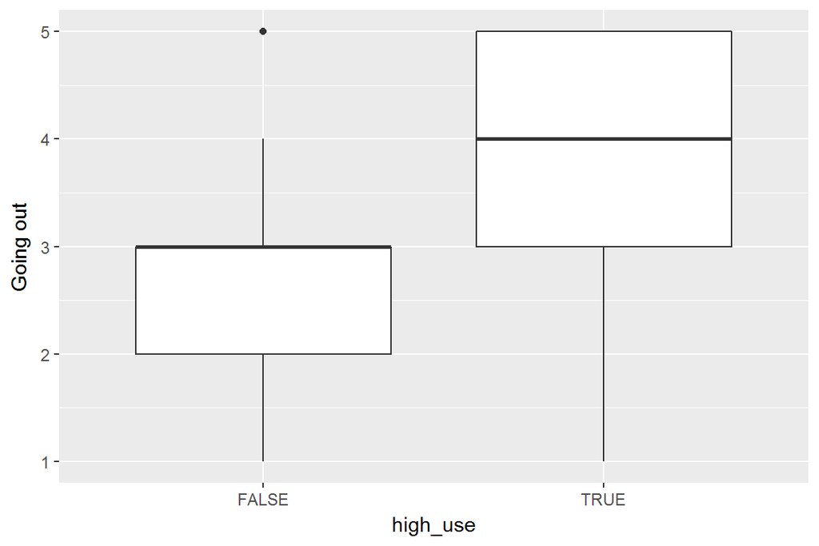

```r
library(ggplot2)
g1 <- ggplot(data = alc, aes(x = high_use, y=goout))
g1 + geom_boxplot() + ylab("Going out")
```

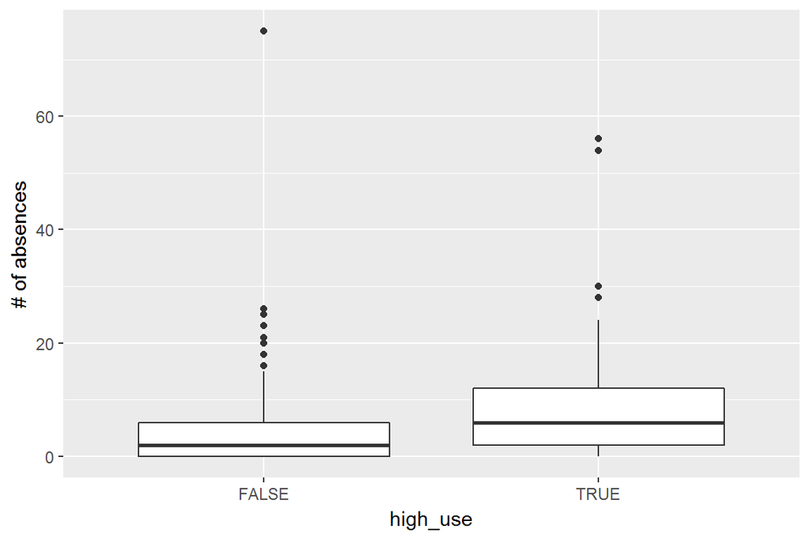

```r
g2 <- ggplot(data = alc, aes(x = high_use, y=absences))
g2 + geom_boxplot() + ylab("# of absences")
```

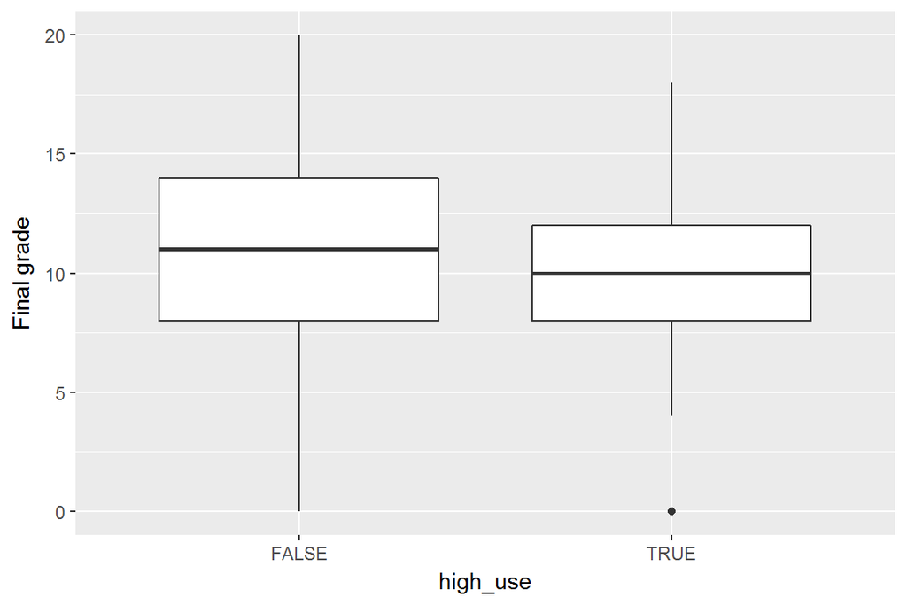

```r
g3 <- ggplot(data = alc, aes(x = high_use, y=G3))
g3 + geom_boxplot() + ylab("Final grade")
```

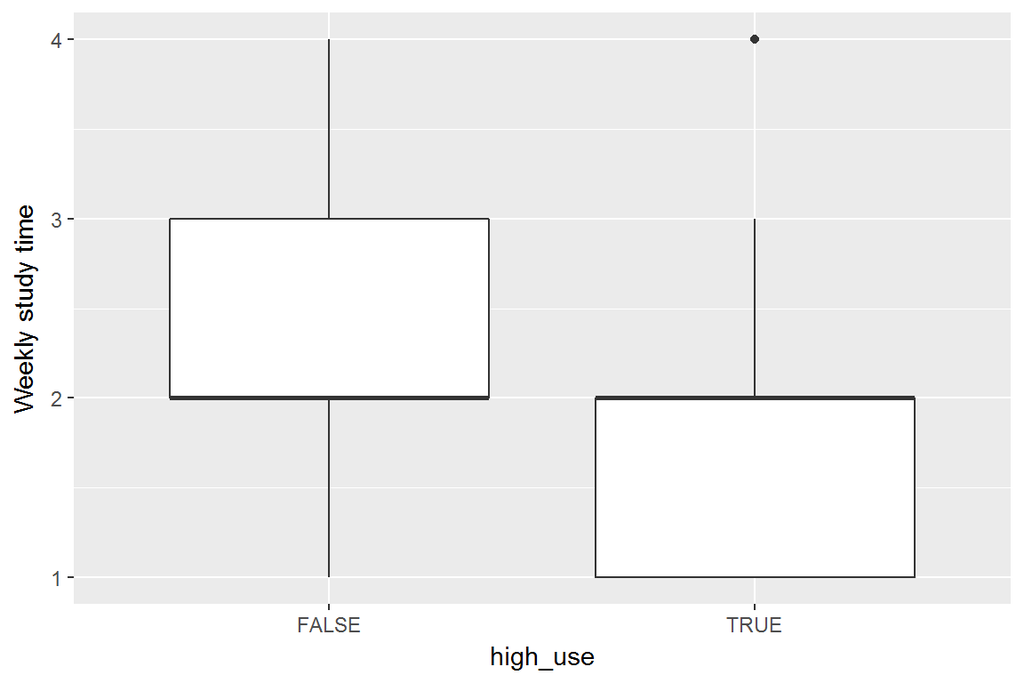

```r
g4 <- ggplot(data = alc, aes(x = high_use, y=studytime))
g4 + geom_boxplot() + ylab("Weekly study time")
```

Logistic regression model with high/low alcohol use and goout, absences, G3, and studytime. Summary of model. Statistically significant positive relationships appear between high_use and goout, high_use and absences. Thus students abusing alcohol are more likely to go out and then miss class Statistically significant negative relationships appear between high_use and studytime. Thus, students abusing alcohol unsurprisingly study less.

Odds ratio and confidence intervals. As the odds ratio is greater than 1, there are positive associations of high alcohol use and going out(OR = 2.1), absences (OR = 1.05), and grade (OR =1.01). The confidence interval of final grade (G3) is 0.95-1.07. AS this includes 1, the positive association should not be considered as significant. Going out and absences have 95% confidence intervals in which both lower limits and high limits are above 1, suggesting their significance. As the odds ratio is less than 1, there are negative associations of high alcohol use and study time (OR = 0.54). The 95% confidence interval is well below 1 (0.38-0.75). These findings are in line with my hypotheses, with the exception of final grade, which seems not to be related to abuse of alcohol.

```r
library(dplyr)
high_low.logreg <- glm(high_use ~ goout + absences + G3 + studytime, data = alc, family = "binomial")
summary(high_low.logreg)
```

```
##
## Call:
## glm(formula = high_use ~ goout + absences + G3 + studytime, family = "binomial",
##     data = alc)
##
## Deviance Residuals:
##     Min       1Q   Median       3Q      Max
## -1.8166  -0.7495  -0.5034   0.8071   2.5083
##
## Coefficients:
##             Estimate Std. Error z value Pr(>|z|)
## (Intercept) -2.62195    0.62727  -4.180 2.92e-05 ***
## goout        0.74536    0.12013   6.204 5.49e-10 ***
## absences     0.05600    0.01643   3.407 0.000656 ***
## G3           0.01269    0.02848   0.446 0.655854
## studytime   -0.60004    0.16852  -3.561 0.000370 ***
## ---
## Signif. codes:  0 '***' 0.001 '**' 0.01 '*' 0.05 '.' 0.1 ' ' 1
##
## (Dispersion parameter for binomial family taken to be 1)
##
##     Null deviance: 462.21  on 381  degrees of freedom
## Residual deviance: 383.16  on 377  degrees of freedom
## AIC: 393.16
##
## Number of Fisher Scoring iterations: 4
```

```r
high_low.OR <- coef(high_low.logreg) %>% exp
high_low.CI <- confint(high_low.logreg) %>% exp
cbind(high_low.OR, high_low.CI)
```

```
##             high_low.OR      2.5 %    97.5 %
## (Intercept)  0.07266094 0.02042166 0.2402599
## goout        2.10719756 1.67554867 2.6863511
## absences     1.05759534 1.02602413 1.0954317
## G3           1.01277150 0.95846241 1.0720167
## studytime    0.54879019 0.38995929 0.7564410
```

```r
high_low.logreg <- glm(high_use ~ goout + absences + studytime, data = alc, family = "binomial")
probabilities <- predict(high_low.logreg, type = "response")
alc <- mutate(alc, probability = probabilities)
alc <- mutate(alc, prediction = ifelse(probability > 0.5, TRUE, FALSE))
select(alc, goout, absences, studytime, high_use, probability, prediction) %>% tail(10)
```

```
##     goout absences studytime high_use probability prediction
## 373     2        0         1    FALSE  0.16853668      FALSE
## 374     3       14         1     TRUE  0.48222661      FALSE
## 375     3        2         3    FALSE  0.12621768      FALSE
## 376     3        7         1    FALSE  0.38579472      FALSE
## 377     2        0         3    FALSE  0.05816886      FALSE
## 378     4        0         2    FALSE  0.32826662      FALSE
## 379     1        0         2    FALSE  0.05081729      FALSE
## 380     1        0         2    FALSE  0.05081729      FALSE
## 381     5        3         1     TRUE  0.68656520       TRUE
## 382     1        0         1     TRUE  0.08841497      FALSE
```

```r
table(high_use = alc$high_use, prediction = alc$prediction)
```

```
##         prediction
## high_use FALSE TRUE
##    FALSE   246   24
##    TRUE     66   46
```

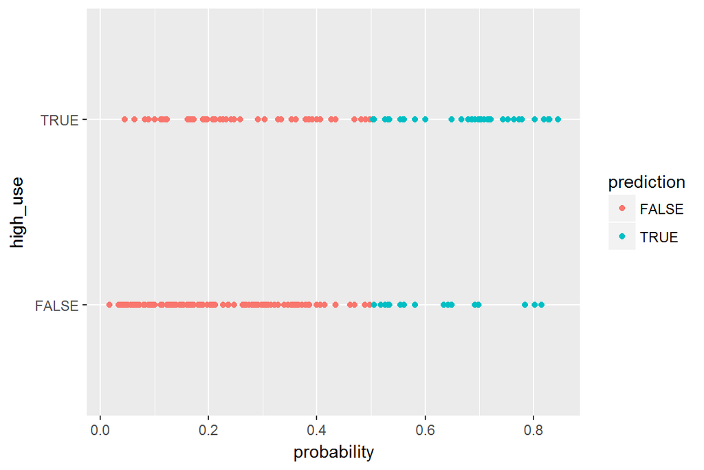

```r
high_use_predictions.g <- ggplot(alc, aes(x = probability, y = high_use, col = prediction))
high_use_predictions.g + geom_point()
```

```r
table(high_use = alc$high_use, prediction = alc$prediction) %>% prop.table() %>% addmargins()
```

```
##         prediction
## high_use      FALSE       TRUE        Sum
##    FALSE 0.64397906 0.06282723 0.70680628
##    TRUE  0.17277487 0.12041885 0.29319372
##    Sum   0.81675393 0.18324607 1.00000000
```

```r
loss_func <- function(class, prob) {
  n_wrong <- abs(class - prob) > 0.5
  mean(n_wrong)
}
print("Average number of wrong predictions using model")
```

```
## [1] "Average number of wrong predictions using model"
```

```r
loss_func(class = alc$high_use, prob = alc$probability)
```

```
## [1] 0.2356021
```

```r
print("Guess of 0")
```

```
## [1] "Guess of 0"
```

```r
loss_func(class = alc$high_use, prob = 0)
```

```
## [1] 0.2931937
```

```r
print("Guess of 1")
```

```
## [1] "Guess of 1"
```

```r
loss_func(class = alc$high_use, prob = 1)
```

```
## [1] 0.7068063
```

```r
library(boot)
high_low.cv <- cv.glm(data = alc, cost = loss_func, glmfit = high_low.logreg, K = 10)
print("Model prediction error with 10-fold cross validation")
```

```
## [1] "Model prediction error with 10-fold cross validation"
```

```r
high_low.cv$delta[1]
```

```
## [1] 0.2434555
```